# Day Two: SESSION ONE

Before we start, make sure you import nltk into your new notebook, as well as numpy and the example texts.

```python
import nltk
import numpy
%matplotlib inline
import pylab
from nltk.book import *
```

```
*** Introductory Examples for the NLTK Book ***
Loading text1, ..., text9 and sent1, ..., sent9
Type the name of the text or sentence to view it.
Type: 'texts()' or 'sents()' to list the materials.
text1: Moby Dick by Herman Melville 1851
text2: Sense and Sensibility by Jane Austen 1811
text3: The Book of Genesis
text4: Inaugural Address Corpus
text5: Chat Corpus
text6: Monty Python and the Holy Grail
text7: Wall Street Journal
text8: Personals Corpus
text9: The Man Who Was Thursday by G . K . Chesterton 1908
```

# Tokenisation Revisted

Upload the file you saved yesterday to the Jupyter notebook.

- Find the file in Jupyter (where you saved it in Excel) to discovery your 'directory path'.
- For Mac go to the find and press command+shift+H for home for the name of your home directory. It should be a combination of your name from when you originally set up for computer.
- Your pathway to the file you saved will be "/User/YourHomeDirectory/Documents/YourFileName.txt"

Save that directory as a string with a variable

```python
#textpath = "/Users/kimdoyle/Documents/welfare.txt"
textpath = "welfare.txt"
```

Python's `os` module can be used to perform tasks such as finding the name of present working directory, changing current working directory, checking if certain files or directories exist at a location, creating new directories and much more!. Let's import os to help us read the file path we just set in Python.

```python
import os
```

```python
text = open(os.path.join(textpath), "r", encoding='UTF-8').read() #open and join a path to the file
#'r' reads the file
#you can print(text) to check this has worked
print(text)
```

```
"RT @kwilli1046: RT if you want Trump to start enforcing a law that's been on the books for 100 years: deporting illegals on welfare! https:…"
"@delemohRIP @Tigerkid777 U get welfare cheques every month kid, go fool some 12yo, I'm not falling for it."
"RT @rcooley123: Ignoring the Real Spending Problem: Tax Cuts for the Rich and Corporate Welfare
https://t.co/uRyHteS5YF"
"RT @ShreeRadhey3: @ChoudhurySalona @narendramodi @RashtrapatiBhvn #SocialServiceByHinduSaints by conducting extensive work in health care,…"
"RT @den2114: Sharia Australia – The More Wives You Have, The More You Get Welfare Benefits @PeterDutton_MP we have become a joke https://t.…"
"RT @joshgnosis: SBS killed off a pre-Budget scoop on the drug testing for welfare trial in exchange for an interview with the PM. https://t…"
"@ScottPresler @nancy_faust The illegals and the welfare losers all need to... be cut off! Fuck them all!The FREEBIE GAME IS OVER LAZY FUCKS!"
"@ChoudhurySalona @narendramodi @RashtrapatiBhvn #SocialServiceByHinduSaints by conducting extensive work in health… https://t.co/rDHPuxoK5A"
"RT @AP4Liberty: I want to build a big beautiful wall… around the welfare state."
"RT @Canadiansparty1: @bren_rem @JustinTrudeau Ottawa &amp; Quebec Is On ALBERTA Welfare https://t.co/ncT5Z5dC3u"
"Countries With The Highest Welfare Status https://t.co/5STuATlgpf https://t.co/NlvJRBEEhn"
"RT @LouisatheLast: Like when he made up ""welfare queens,"" or when he let queer people die of AIDS while his press secretary made jokes abou…"
"@PoleAtHarvard @bobperryday1 @MarkDice We need to stop paying for illegals, pass drug test before collecting welfar… https://t.co/NU7kg7Hpf2"
"RT @Shanny20121670: @JackPosobiec Every single POS on welfare protesting... needs to get cut off for life!!!"
"RT @CartwheelPrint: Welfare youths given jobs in retail https://t.co/nu4PnSMbxM Tone of the article is so rude. Work for free to be a retai…"
"RT @StacyLStiles: How to create a SocialState:
•HealthCare
•Poverty
•Debt
•Gun Control
•Welfare
•Education
•Religion
•Class Warfare

Sound…"
"Tory home ownership schemes more likely to benefit the better-off https://t.co/AW9bUYcfOn via @Welfare_Weekly"
"Nurses and midwives are leaving in droves, new figures suggests https://t.co/7h64lZu6p9 via @Welfare_Weekly"
"RT @itrimboli: Paying ppl on welfare $4 an hr is not ""providing opportunities"". It's exploiting those who r extremely vulnerable!!

https:/…"
"RT @rose10052: .@MaxineWaters
Welfare for illegals
Sanctuary cities
Open borders
Don't live amongst her people
Serial liar
#NeverMaxine…"
"@ps12352 @DhananjayPraj15 @montu2005 @GZANWAR @TOIMumbai With massive number of Social service/welfare campaigns,… https://t.co/vj6GPB4T88"
```

[output cut: 14042 more lines]

```
"RT @leJDD: Réforme du Code du Travail : déjà une manifestation prévue le 12 septembre https://t.co/I9NpNSoZ92 https://t.co/coLfTZ2LHV"
"https://t.co/kJBbuvwe1k to earn Daily Rewards and Cash 💵 💵 for Trying free apps. Use code KUY0K for 60 Bonus Points! https://t.co/nRKup8R3IN"
"RT @kyunghyang: ""응답하라 안철수""
https://t.co/UOJmcjcimQ"
"@andreasdotorg Well, to be honest that's more of an oversight of the compilers, not inserting stack probing into the generated code."
"Whatever the case, I stand by @eth_classic. Unstoppable code should never be stopped!!"
"Why an unpopular Trump and his party can still win https://t.co/XV5Q5WtbWi"
"☆【EXカード】6月の特典発表！！☆

《この1枚からさらなる楽しみを♪》

進化を遂げたEXカード!!6月の特典はこちら♪♪毎月変わる豪華特典から目が離せない!!
https://t.co/VyrI5VHy1K"
"RT @kyunghyang: 삼성일반노조가 합법적인 노조로 인정받기까지는 14년이라는 세월이 걸렸다.
https://t.co/8mzHF6XiQg"
```

### *Challenge!*

You now have a twitter dataset of your own. Try to tokenize the data using the exact same steps as you used to tokenize the single tweet in the previous session. This time, your first variable is 'text', rather than 'tweet'.

```python
from nltk.tokenize.casual import (TweetTokenizer, casual_tokenize)
text_tokens = casual_tokenize(text)
text_tokens[1:12]
```

```
['RT',
 '@kwilli1046',
 ':',
 'RT',
 'if',
 'you',
 'want',
 'Trump',
 'to',
 'start',
 'enforcing']
```

Now you can see that the data is a list of words and punctuation. Fortunately, our special tweet tokeniser is clever enough to recognise that @ symbols are part of user names, although no tokeniser is perfect and you will most likely need to perform data cleaning on a big dataset. This is beyond the scope of this tutorial. However, we can remove punctuation, capitalised words and 'stopwords', to get more insights into our data. First, we need to understand how loops work...

## Python Basics: Loops

We can use Python to automate tasks, such as performing a function on all items in a list. In our case, we want Python to check if each word in our tweet corpus is alphabetical and lower case. To do that, we'll have to teach the computer how to repeat things. We do this by creating something called a loop.

This is the general form of a 'for' loop:

```
for item in collection:
do things with item
```

Loops are used for lots of things in programming and there are many types of loops. Today we are only interested in for loops and our list of tweets.

We are going to create a list and assign it a variable. We will use this variable in our loop to create fruit salad!

```python
fruits = ["cherry", "pineapple", "grape"]
print("Just add:")
for x in fruits:
    print(" - " + x)

print("and mix")
```

```
Just add:
 - cherry
 - pineapple
 - grape
and mix
```

```python
for word in sent2:
    if len(word) > 5:
        print("..."+word, end='')
```

```
...family...Dashwood...settled...Sussex
```

Another way to write this is to save it as a new list and give it a variable name:

```python
long_words = [word for word in sent2 if len(word) > 5]
long_words
```

```
['family', 'Dashwood', 'settled', 'Sussex']
```

We can use numerical operators to refine the types of searches we ask Python to run. We can use the following relational operators:

### Common relationals

| Relational | Meaning |
| --- | --- |
| < | less than |
| <= | less than or equal to |
| == | equal to (note this is two "=" signs, not one) |
| != | not equal to |
| > | greater than |
| >= | greater than or equal to |

### *Challenge!*

```python
print("Orig: " + str(sent4))
longer = [word for word in sent4 if len(word) > 4]
print("Long " + str(longer))
threes = [word for word in sent4 if len(word) == 3]
print("Long " + str(threes))
[]
```

```
Orig: ['Fellow', '-', 'Citizens', 'of', 'the', 'Senate', 'and', 'of', 'the', 'House', 'of', 'Representatives', ':']
Long ['Fellow', 'Citizens', 'Senate', 'House', 'Representatives']
Long ['the', 'and', 'the']
```

```python
lower_tokens = [word.lower() for word in text_tokens if len(word) >1]
lower_tokens
```

```
['rt',
 '@kwilli1046',
 'rt',
 'if',
 'you',
 'want',
 'trump',
 'to',
 'start',
 'enforcing',
 'law',
 "that's",
 'been',
 'on',
 'the',
 'books',
 'for',
 '100',
 'years',
 'deporting',
 'illegals',
 'on',
 'welfare',
 'https',
 '@delemohrip',
 '@tigerkid777',
 'get',
 'welfare',
 'cheques',
 'every',
 'month',
 'kid',
 'go',
 'fool',
 'some',
 '12yo',
 "i'm",
 'not',
 'falling',
 'for',
```

[output cut: 946 more lines]

```
 'thousands',
 'of',
 'migrants',
 'https://t.co/v3n1hcmda8',
 'rt',
 '@stacylstiles',
 'how',
 'to',
 'create',
 'socialstate',
 'healthcare',
 'poverty',
 'debt',
 'gun',
 ...]
```

```python
ngrams = nltk.collocations.ngrams
from collections import Counter
```

```python
hashtags = [word for word in lower_tokens if word.startswith("#")]
hashtag_counts = Counter(hashtags)
hashtag_counts.most_common(10)
```

```
[('#centrelink', 259),
 ('#auspol', 181),
 ('#notmydebt', 108),
 ('#giveaway', 62),
 ('#robodebt', 55),
 ('#code', 26),
 ('#socialservicebyhindusaints', 21),
 ('#hacking', 19),
 ('#cybe', 18),
 ('#supportsmal', 18)]
```

```python
ats = [word for word in lower_tokens if word.startswith("@")]
at_counts = Counter(ats)
at_counts.most_common(10)
```

```
[('@asher_wolf', 609),
 ('@senatorludlam', 366),
 ('@centrelink', 339),
 ('@:', 167),
 ('@kingbelltorres', 164),
 ('@klomenn', 162),
 ('@hughriminton', 135),
 ('@slayking0', 129),
 ('@smh', 121),
 ('@kingboss0_', 113)]
```

## Key Concepts: Preprocessing

### Common operators

| Operator | Purpose |
| --- | --- |
| s.startswith(t) | test if s starts with t |
| s.endswith(t) | test if s ends with t |
| t in s | test if t is a substring of s |
| s.islower() | test if s contains cased characters and all are lowercase |
| s.isupper() | test if s contains cased characters and all are uppercase |
| s.isalpha() | test if s is non-empty and all characters in s are alphabetic |
| s.isalnum() | test if s is non-empty and all characters in s are alphanumeric |
| s.isdigit() | test if s is non-empty and all characters in s are digits |
| s.istitle() | test if s contains cased characters and is titlecased (i.e. all words in s have initial capitals) |

Now we are ready to remove punctuation and capitalised words from our data

```python
print(str(len(lower_tokens)))
clean_tokens = [word for word in lower_tokens if (word.isalpha() and not word.startswith("http")) or word.startswith("@") or word.startswith("#")]
print(str(len(clean_tokens)))
clean_tokens[50:60]
```

```
109691
97398
```

```
['welfare',
 'rt',
 '@shreeradhey3',
 '@choudhurysalona',
 '@narendramodi',
 '@rashtrapatibhvn',
 '#socialservicebyhindusaints',
 'by',
 'conducting',
 'extensive']
```

Python still thinks lower case words and capitalised words are different words e.g. 'Left' and 'left' would be considered two different words. We can change this by making all the words lowercase using the `s.lower()` method.

```python
#too late
```

Try running some NLTK operations on the data, such as `something.collocations()` what happens?

```python
import numpy
%matplotlib inline
#clean_tokens.dispersion_plot(["whale"])
```

```python
print(type(clean_tokens))
print(type(text1))
```

```
<class 'list'>
<class 'nltk.text.Text'>
```

To perform special NLTK tasks like `.concordance(), .collocations()` and `.similar()`, we need to convert our 'list' in an NLTK Text. Forunately, this is fairly straightforward.

```python
from nltk import Text
nltk_tokens = Text(clean_tokens)
print(type(nltk_tokens))
```

```
<class 'nltk.text.Text'>
```

Now try collocations!

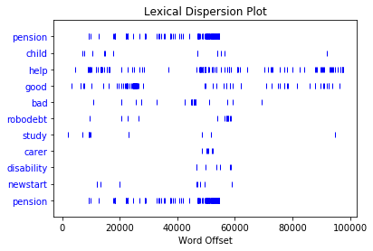

```python
nltk_tokens.dispersion_plot(["pension", "child", "help", "good", "bad", "robodebt", "study", "carer", "disability", "newstart", "pension"])
```

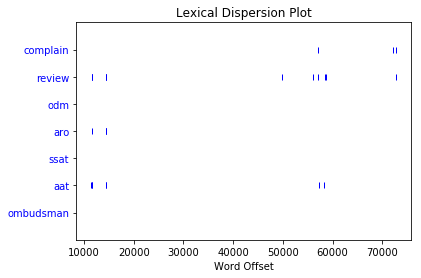

```python
nltk_tokens.dispersion_plot(["complain", "review", "odm", "aro", "ssat", "aat", "ombudsman"])
```

## Key Concepts: Stopwords

Typically, a lot of space is taken up in texts by little words like 'and' and 'of' and 'the' which don't add a lot to our understanding of text. These are called 'stop words'. It will help our analysis if we exclude them.

```python
from nltk.probability import FreqDist
from collections import Counter
freq_dist = FreqDist(clean_tokens)
freq_dist.most_common(10)
```

```
[('rt', 5094),
 ('to', 2277),
 ('code', 2259),
 ('for', 2236),
 ('centrelink', 2154),
 ('the', 2126),
 ('is', 1386),
 ('on', 1170),
 ('you', 1166),
 ('use', 1041)]
```

```python
from nltk.corpus import stopwords
stopps = nltk.corpus.stopwords.words("english") + ["rt", "via", "ping", "@:", "http", "https", "15", "10"]
unstop_tokens = [word for word in lower_tokens if word not in stopps]
```

```python
for word in stopps:
    print(word)
```

```
i
me
my
myself
we
our
ours
ourselves
you
your
yours
yourself
yourselves
he
him
his
himself
she
her
hers
herself
it
its
itself
they
them
their
theirs
themselves
what
which
who
whom
this
that
these
those
am
is
are
```

[output cut: 102 more lines]

[output not shown]

```python
for word in clean_tokens:
    print(word)
```

[output not shown]

[output cut: 97771 more lines]

[output not shown]

```python
freq_dist = FreqDist(unstop_tokens)
freq_dist.most_common(20)
```

```
[('code', 2259),
 ('centrelink', 2154),
 ('use', 1041),
 ('phones', 769),
 ('hacking', 761),
 ('@asher_wolf', 609),
 ('welfare', 563),
 ('discount', 557),
 ('like', 457),
 ('recipients', 441),
 ('shop', 427),
 ("i'm", 397),
 ('@senatorludlam', 366),
 ('fuck', 340),
 ('@centrelink', 339),
 ('fucking', 338),
 ('get', 334),
 ('holy', 329),
 ('https://t.co/tu8i9hxoud', 329),
 ('shitting', 328)]
```

[figure not shown]

```python
freq_dist.plot(20, cumulative=False, title="Top 'welfare' word frequencies")
```

```python
nltk_tokens.common_contexts(["welfare", "centrelink"])
```

```
on_rt for_not for_and off_rt in_fraud
```

### *Challenge!*

- remove capitalised letter from alpha
- Make sure you convert it to NLTK Text first and save it to a new variable
- Remove stopwords
- Run the FreqDist function
- Find the `most.common()[:20]` words

```python
print(str(len(lower_tokens)))
clean_tokens = [word for word in lower_tokens if (word.isalpha() and not word.startswith("http")) or word.startswith("@") or word.startswith("#")]
print(str(len(clean_tokens)))
nltk_tokens = Text(clean_tokens)
print(str(len(nltk_tokens)))
```

```
109691
97398
97398
```

```python
from nltk.corpus import stopwords
stopps = nltk.corpus.stopwords.words("english") + ["rt", "via", "ping", "@:", "http", "https", "15", "10"]
unstop_tokens = [word for word in lower_tokens if word not in stopps]
```

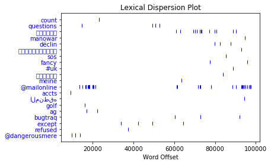

```python
unique_tokens = list(set(clean_tokens))
nltk_tokens.dispersion_plot(unique_tokens[:20])
```

```python
nltk_tokens.collocations(window_size=10, num=10)
```

```
hacking phones; @senatorludlam hang; cried ill; cried terminally;
shitting holy; cried cut; cried man; fucking shitting; fucking holy;
shitting fuck
```

```python
nltk_tokens.similar("centrelink")
```

```
#centrelink phone code welfare the this @centrelink it work check why
ato you not have we need is how society
```

```python
nltk_tokens.concordance("centrelink", width=120, lines=10)
```

```
Displaying 10 of 2154 matches:
vice restored @egracecontact aware of issues impacting centrelink online accts express plus centrelink sorry for inconve
 issues impacting centrelink online accts express plus centrelink sorry for inconve @centrelink submitted sickness certi
 disabilit just cried and cried terminally ill man has centrelink payments cut for interview via @illawarramerc @tony_sh
e apps we re urgently investigatin rt @annadorablegirl centrelink is being fucked still have no money if you can help ev
 so much https rt @7_jenkinson this lnp gov has turned centrelink into biggest organised crime ring specialising in exto
 your wallet you will need to contact us we can assure centrelink web site completely unresponsive today day ending in @
 down @denisgiles1947 we are aware of issues affecting centrelink online accounts this is under urgent investigation we
ils page is that normal rt @my_environment at least to centrelink supports sustainable jobs the logging sectors scored m
st conservatio rt @7_jenkinson this lnp gov has turned centrelink into biggest organised crime ring specialising in exto
t job did not do those end up with black mark on their centrelink file @centrelink not going to happen not going to wast
```

# Day Two: SESSION 2

### *Challenge!*

Time to experiment with your team!

```python
import nltk
import matplotlib.pyplot as plt
%matplotlib inline
```

```python
from nltk.corpus import stopwords
clean_tokens = [word for word in lower_tokens if (word.isalpha() and not word.startswith("http")) or word.startswith("@") or word.startswith("#")]

stopps = nltk.corpus.stopwords.words("english") + ["rt", "via", "ping", "@:", "15", "10"]
unstop_tokens = [word for word in clean_tokens if word not in stopps]

freq_dist = FreqDist(unstop_tokens)
freq_dist.most_common(20)
```

```
[('code', 2259),
 ('centrelink', 2154),
 ('use', 1041),
 ('phones', 769),
 ('hacking', 761),
 ('@asher_wolf', 609),
 ('welfare', 563),
 ('discount', 557),
 ('like', 457),
 ('recipients', 441),
 ('shop', 427),
 ('@senatorludlam', 366),
 ('fuck', 340),
 ('@centrelink', 339),
 ('fucking', 338),
 ('get', 334),
 ('holy', 329),
 ('shitting', 328),
 ('hang', 306),
 ('promo', 294)]
```

```python
hashtags = [word for word in unstop_tokens if word.startswith("#")]
hashtag_counts = Counter(hashtags)
hashtag_counts.most_common(10)
```

```
[('#centrelink', 259),
 ('#auspol', 181),
 ('#notmydebt', 108),
 ('#giveaway', 62),
 ('#robodebt', 55),
 ('#code', 26),
 ('#socialservicebyhindusaints', 21),
 ('#hacking', 19),
 ('#cybe', 18),
 ('#supportsmal', 18)]
```

```python
ats = [word for word in unstop_tokens if word.startswith("@")]
at_counts = Counter(ats)
at_counts.most_common(10)
```

```
[('@asher_wolf', 609),
 ('@senatorludlam', 366),
 ('@centrelink', 339),
 ('@kingbelltorres', 164),
 ('@klomenn', 162),
 ('@hughriminton', 135),
 ('@slayking0', 129),
 ('@smh', 121),
 ('@kingboss0_', 113),
 ('@finbaromallon', 85)]
```

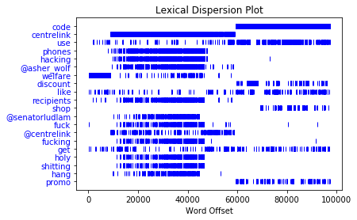

```python
token_counts = Counter(unstop_tokens)
most_common_tokens = [token for token, count in token_counts.most_common(20)]
nltk_tokens.dispersion_plot(most_common_tokens)
```

```python
[token for token, count in token_counts.most_common(15)]
```

```
['code',
 'centrelink',
 'use',
 'phones',
 'hacking',
 '@asher_wolf',
 'welfare',
 'discount',
 'like',
 'recipients',
 'shop',
 '@senatorludlam',
 'fuck',
 '@centrelink',
 'fucking']
```

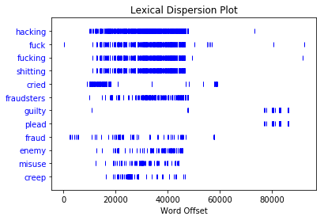

```python
nltk_tokens.dispersion_plot(["hacking","fuck","fucking","shitting","cried","fraudsters","guilty","plead","fraud","enemy","misuse","creep"])
```

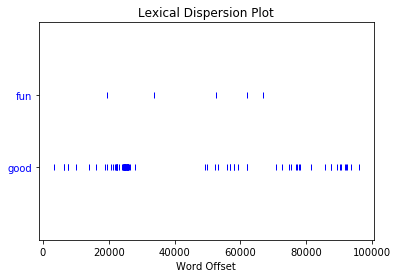

```python
nltk_tokens.dispersion_plot(["fun","good"])
```

```python
nltk_tokens.concordance("code")
```

```
Displaying 25 of 2259 matches:
im your free ride on uber with promo code miguelt cheaper than lyft crazy prom
ers urged to send id number to short code to verify registration sta @iebckeny
ers urged to send id number to short code to verify registration sta @iebckeny
ers urged to send id number to short code to verify registration sta @iebckeny
ers urged to send id number to short code to verify registration sta @iebckeny
ers urged to send id number to short code to verify registration sta @iebckeny
ers urged to send id number to short code to verify registration sta @iebckeny
ers urged to send id number to short code to verify registration sta @iebckeny
ers urged to send id number to short code to verify registration sta @iebckeny
ers urged to send id number to short code to verify registration sta @iebckeny
ers urged to send id number to short code to verify registration sta @iebckeny
ers urged to send id number to short code to verify registration sta @iebckeny
ers urged to send id number to short code to verify registration sta @iebckeny
ers urged to send id number to short code to verify registration sta @iebckeny
ers urged to send id number to short code to verify registration sta @iebckeny
ers urged to send id number to short code to verify registration sta @iebckeny
ers urged to send id number to short code to verify registration sta rt @savin
t @savinijason1 selling savini jason code #fridaythe13ththegame #savinijason @
par thème que contient la réforme du code du travail version macron internet t
ersion macron internet trends report code conference by @kpcb via @eraser rt @
lothrooms sexy shell bikini discount code for trend ステンカラーコート rt @redprice_50
 euromaxplay casino no deposit bonus code for sun palace casino no #cryptocurr
d #monero #mining unter rabatt promo code oergul canalvod vous offre sur tout
offre sur tout son catalogue avec le code tonight is the night pm need lyft us
 is the night pm need lyft use promo code on the lyft app rt @fuggirls just sa
```